# Forecasting of Tourism to Japan

# Visualizing the Forecast and Components

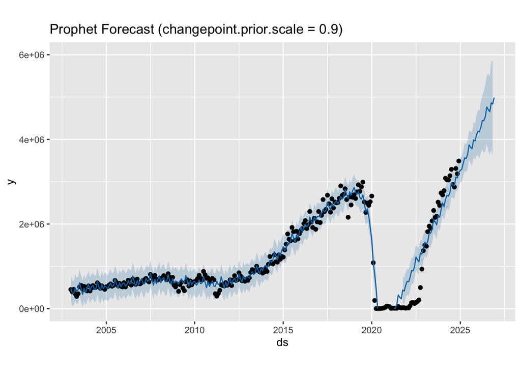

```r
plot(model3, forecast3) + ggtitle("Prophet Forecast (changepoint.prior.scale = 0.9)") + ylim(0,6000000)
```

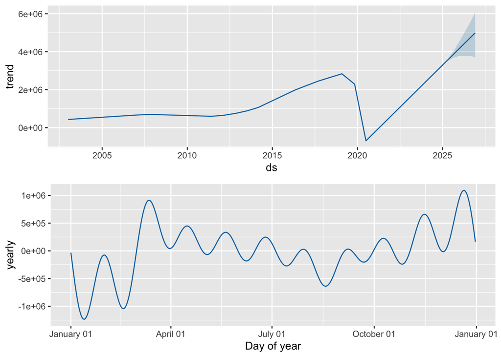

```r
prophet_plot_components(model3, forecast3)
```

# Conclusion

As a result, the data shows a clear long-term upward trend with noticeable seasonal fluctuations and a large structural break during the COVID-19 period.

A small value (0.05) produced an overly smooth trend, the trend component remains almost linear and fails to capture major structural changes in the data. A large value (0.9) led to overfitting and unrealistic forecasts. The model becomes overly sensitive to fluctuations in the data, especially no zigzag blue predicted during sharp drop in pandemic and narrower band. An intermediate value (0.3) provided a more reasonable outcome.

Seasonality: The yearly graph shows seasonal fluctuations in tourist arrivals. Visitor numbers tend to be higher during certain periods of the year and lower during others i.e Sakura blossom season during March, reflecting seasonal travel patterns. This may be related to holiday periods, favorable weather conditions, and peak tourism seasons in Japan.

Overall, the Prophet model can capture the general pattern of the series, although extreme shocks such as the COVID-19 remain difficult to forecast accurately.

# References

- Japan National Tourism Organization (JNTO). International Visitor Statistics. https://www.jnto.go.jp/statistics/data/_files/20260218_1615-5.xlsx